# **Bootcamp Ciencia de Datos e Inteligencia Artificial**

## **Proyecto Módulo 2 Limpieza y preprocesado de datos**

## ¿Qué construirás?

Un análisis sobre un conjunto de datos para su posterior modelado. Este proyecto se dividirá en 4 secciones:

- Análisis Exploratorio
- Limpieza de datos
- Procesamiento de datos
- Reducción de dimensiones

## Conjunto de datos para analizar.

Se tiene información de Lending Club, empresa estadounidense de préstamos con sede en San Francisco, California. En dicha compañía, los prestatarios pueden acceder fácilmente a préstamos con tasas de interés bajas. El dataset contiene datos de todos los préstamos emitidos durante el periodo 2007-2015, con el estado actual del préstamo (actual, cancelado, completamente pagado) y la información de pago más reciente.

```
/content/drive/My Drive/Módulo 2/Proyecto
```

## Análisis Exploratorio

```
El número de filas del dataframe es: 887379
El número de columnas del dataframe es: 74

Total columnas numéricas: 51
Total columnas no numéricas: 23
Filas duplicadas: 0

Columnas no numéricas: ['term', 'grade', 'sub_grade', 'emp_title', 'emp_length', 'home_ownership', 'verification_status', 'issue_d', 'loan_status', 'pymnt_plan', 'url', 'desc', 'purpose', 'title', 'zip_code', 'addr_state', 'earliest_cr_line', 'initial_list_status', 'last_pymnt_d', 'next_pymnt_d', 'l…
Columnas numéricas: ['id', 'member_id', 'loan_amnt', 'funded_amnt', 'funded_amnt_inv', 'int_rate', 'installment', 'annual_inc', 'dti', 'delinq_2yrs', 'inq_last_6mths', 'mths_since_last_delinq', 'mths_since_last_record', 'open_acc', 'pub_rec', 'revol_bal', 'revol_util', 'total_acc', 'out_prncp', 'out…
```

```
El número de variables con completitud mayor al 50% es: 53
```

```
['id', 'member_id', 'loan_amnt', 'funded_amnt', 'funded_amnt_inv', 'term', 'int_rate', 'installment', 'grade', 'sub_grade', 'emp_title', 'emp_length', 'home_ownership', 'annual_inc', 'verification_status', 'issue_d', 'loan_status', 'pymnt_plan', 'url', 'purpose', 'title', 'zip_code', 'addr_state', '…
```

```
(887379, 52)
```

### **Análisis Univariado**

```
count    887379.000000
mean      14755.264605
std        8435.455601
min         500.000000
25%        8000.000000
50%       13000.000000
75%       20000.000000
max       35000.000000
Name: loan_amnt, dtype: float64

count      887379
unique         10
top       Current
freq       601779
Name: loan_status, dtype: object

loan_status
Charged Off                                             45248
Current                                                601779
Default                                                  1219
Does not meet the credit policy. Status:Charged Off       761
Does not meet the credit policy. Status:Fully Paid       1988
Fully Paid                                             207723
In Grace Period                                          6253
Issued                                                   8460
Late (16-30 days)                                        2357
Late (31-120 days)                                      11591
Name: loan_amnt, dtype: int64
```

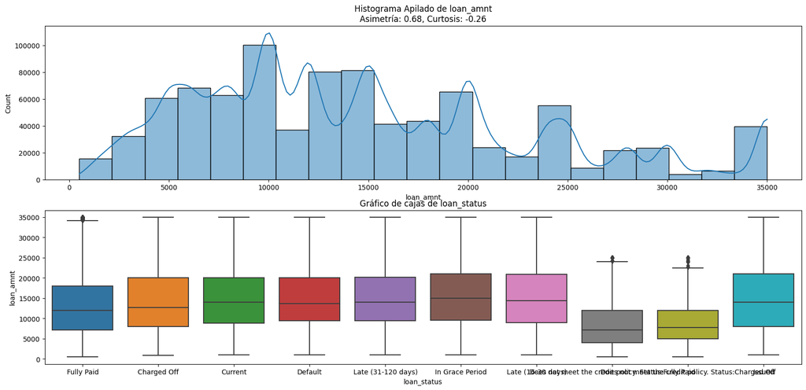

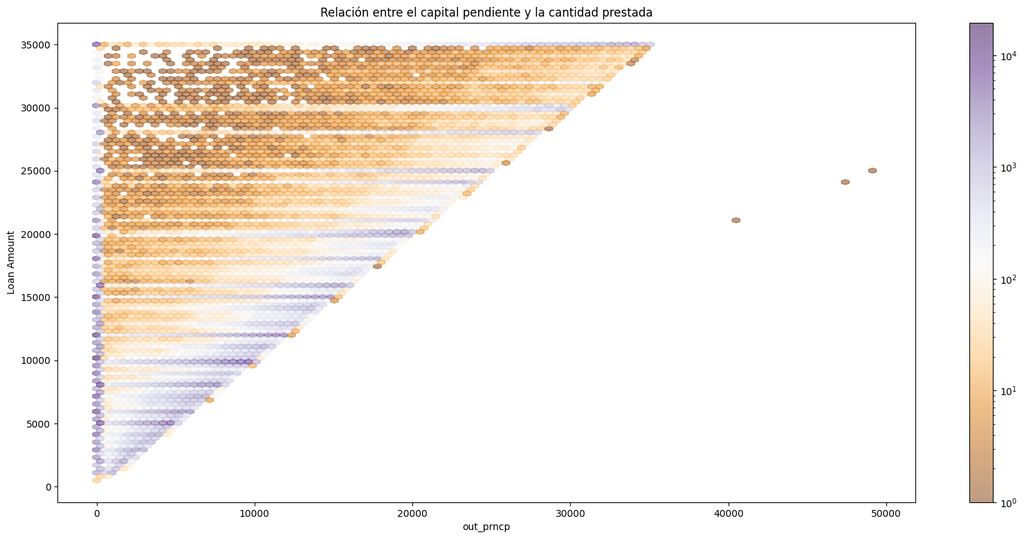

|  | loan_amnt |
| --- | --- |
| loan_amnt | 1.000000 |
| funded_amnt | 0.999263 |
| funded_amnt_inv | 0.997115 |
| installment | 0.944977 |
| out_prncp_inv | 0.646898 |
| out_prncp | 0.646897 |
| total_rec_int | 0.533916 |
| total_pymnt_inv | 0.475655 |
| total_pymnt | 0.474626 |
| total_rec_prncp | 0.390473 |
| revol_bal | 0.333580 |
| annual_inc | 0.332698 |
| tot_cur_bal | 0.328782 |
| total_rev_hi_lim | 0.312439 |
| last_pymnt_amnt | 0.229244 |
| total_acc | 0.222639 |
| open_acc | 0.198906 |
| int_rate | 0.145023 |
| revol_util | 0.119565 |
| recoveries | 0.073150 |
| member_id | 0.064461 |
| id | 0.063803 |
| collection_recovery_fee | 0.052205 |
| total_rec_late_fee | 0.031395 |
| dti | 0.020675 |
| acc_now_delinq | 0.003947 |
| delinq_2yrs | -0.000159 |
| tot_coll_amt | -0.004275 |
| collections_12_mths_ex_med | -0.016650 |
| inq_last_6mths | -0.034168 |
| pub_rec | -0.081177 |

**Análisis del monto de los prestamos**: La media del monto del préstamo es un poco mayor que la mediana; sin embargo, se puede decir que del 25% de los préstamos (alrededor de 221.844) son de 20.000 o más, pero debe tenerse en cuenta que la dispersión de los datos es considerablmente alta, puesto que la desviación estándar es de 8.435.

**Análisis del estado de los préstamos**: Hay 10 categorías para el estado del préstamo, lo que sugiere que hay varios estados posibles de la situación del préstamo, siendo el más común o frecuente (601,779) el *Current*, lo que implica que la mayoría de los préstamos están en curso y que la entidad financiera está teniendo un buen desempeño.

### **Análisis multivariado**

|  | id | member_id | loan_amnt | funded_amnt | funded_amnt_inv | int_rate | installment | annual_inc | dti | delinq_2yrs | inq_last_6mths | open_acc | pub_rec | revol_bal | revol_util | total_acc | out_prncp | out_prncp_inv | total_pymnt | total_pymnt_inv | total_rec_prncp | total_rec_int | total_rec_late_fee | recoveries | collection_recovery_fee | last_pymnt_amnt | collections_12_mths_ex_med | acc_now_delinq | tot_coll_amt | … |
| --- | --- | --- | --- | --- | --- | --- | --- | --- | --- | --- | --- | --- | --- | --- | --- | --- | --- | --- | --- | --- | --- | --- | --- | --- | --- | --- | --- | --- | --- | --- |
| id | 1.000000 | 0.999443 | 0.063803 | 0.066058 | 0.071502 | -0.142963 | 0.025347 | 0.033990 | 0.067781 | 0.049648 | -0.126950 | 0.088720 | 0.080126 | 0.036457 | -0.055153 | 0.031519 | 0.558686 | 0.558651 | -0.597261 | -0.592687 | -0.556328 | -0.462019 | -0.076043 | -0.114386 | -0.072821 | -0.228875 | 0.051334 | 0.016855 | 0.004260 | … |
| member_id | 0.999443 | 1.000000 | 0.064461 | 0.066754 | 0.072308 | -0.142205 | 0.026036 | 0.034146 | 0.067824 | 0.049904 | -0.127257 | 0.088838 | 0.080788 | 0.036416 | -0.054873 | 0.031692 | 0.559138 | 0.559103 | -0.596768 | -0.592071 | -0.556028 | -0.461098 | -0.076388 | -0.114473 | -0.072818 | -0.228369 | 0.051445 | 0.016961 | 0.004292 | … |
| loan_amnt | 0.063803 | 0.064461 | 1.000000 | 0.999263 | 0.997115 | 0.145023 | 0.944977 | 0.332698 | 0.020675 | -0.000159 | -0.034168 | 0.198906 | -0.081177 | 0.333580 | 0.119565 | 0.222639 | 0.646897 | 0.646898 | 0.474626 | 0.475655 | 0.390473 | 0.533916 | 0.031395 | 0.073150 | 0.052205 | 0.229244 | -0.016650 | 0.003947 | -0.004275 | … |
| funded_amnt | 0.066058 | 0.066754 | 0.999263 | 1.000000 | 0.998025 | 0.145160 | 0.946005 | 0.332466 | 0.021075 | 0.000151 | -0.034711 | 0.199387 | -0.080836 | 0.333435 | 0.120061 | 0.222575 | 0.648838 | 0.648839 | 0.473286 | 0.474502 | 0.389242 | 0.532864 | 0.031075 | 0.072687 | 0.051955 | 0.228772 | -0.016491 | 0.004051 | -0.004275 | … |
| funded_amnt_inv | 0.071502 | 0.072308 | 0.997115 | 0.998025 | 1.000000 | 0.145205 | 0.943632 | 0.331420 | 0.022185 | 0.000648 | -0.038880 | 0.200004 | -0.079790 | 0.331736 | 0.120759 | 0.222793 | 0.651545 | 0.651556 | 0.468848 | 0.474062 | 0.384877 | 0.530382 | 0.027961 | 0.070751 | 0.049392 | 0.227510 | -0.016063 | 0.004245 | -0.004274 | … |
| int_rate | -0.142963 | -0.142205 | 0.145023 | 0.145160 | 0.145205 | 1.000000 | 0.133075 | -0.072786 | 0.079903 | 0.055178 | 0.227650 | -0.010381 | 0.052156 | -0.035708 | 0.269139 | -0.038618 | 0.042671 | 0.042529 | 0.170506 | 0.171479 | 0.054975 | 0.445679 | 0.057150 | 0.106840 | 0.070867 | 0.101179 | 0.013336 | 0.026478 | 0.001130 | … |
| installment | 0.025347 | 0.026036 | 0.944977 | 0.946005 | 0.943632 | 0.133075 | 1.000000 | 0.326182 | 0.014333 | 0.007876 | -0.003623 | 0.183868 | -0.069967 | 0.316588 | 0.131798 | 0.200409 | 0.548159 | 0.548154 | 0.514954 | 0.515817 | 0.449439 | 0.498665 | 0.041810 | 0.074546 | 0.054313 | 0.238447 | -0.014108 | 0.006580 | -0.003526 | … |
| annual_inc | 0.033990 | 0.034146 | 0.332698 | 0.332466 | 0.331420 | -0.072786 | 0.326182 | 1.000000 | -0.087410 | 0.047470 | 0.035193 | 0.138392 | -0.008341 | 0.295784 | 0.036730 | 0.187335 | 0.211213 | 0.211254 | 0.160879 | 0.160821 | 0.149993 | 0.128535 | 0.013500 | 0.007717 | 0.006630 | 0.090964 | -0.003936 | 0.014775 | 0.001096 | … |
| dti | 0.067781 | 0.067824 | 0.020675 | 0.021075 | 0.022185 | 0.079903 | 0.014333 | -0.087410 | 1.000000 | -0.002831 | -0.008106 | 0.144250 | -0.022926 | 0.067277 | 0.087844 | 0.108056 | 0.059319 | 0.059282 | -0.041529 | -0.040336 | -0.052056 | 0.008380 | -0.005748 | 0.001162 | 0.002159 | -0.029351 | -0.000292 | 0.003205 | -0.002084 | … |
| delinq_2yrs | 0.049648 | 0.049904 | -0.000159 | 0.000151 | 0.000648 | 0.055178 | 0.007876 | 0.047470 | -0.002831 | 1.000000 | 0.021375 | 0.051189 | -0.011004 | -0.032486 | -0.017261 | 0.122713 | 0.031619 | 0.031608 | -0.031902 | -0.031470 | -0.038393 | 0.001665 | 0.017432 | -0.000729 | 0.000989 | -0.019518 | 0.063016 | 0.130326 | 0.000207 | … |
| inq_last_6mths | -0.126950 | -0.127257 | -0.034168 | -0.034711 | -0.038880 | 0.227650 | -0.003623 | 0.035193 | -0.008106 | 0.021375 | 1.000000 | 0.111235 | 0.056870 | -0.017556 | -0.087773 | 0.135584 | -0.106736 | -0.106756 | 0.077683 | 0.073846 | 0.062385 | 0.085585 | 0.031637 | 0.045590 | 0.034007 | 0.059998 | 0.006850 | -0.005329 | 0.003171 | … |
| open_acc | 0.088720 | 0.088838 | 0.198906 | 0.199387 | 0.200004 | -0.010381 | 0.183868 | 0.138392 | 0.144250 | 0.051189 | 0.111235 | 1.000000 | -0.025301 | 0.224542 | -0.143907 | 0.695075 | 0.171799 | 0.171802 | 0.042593 | 0.043831 | 0.031149 | 0.061223 | -0.009606 | 0.001560 | 0.003217 | 0.028050 | 0.009610 | 0.017752 | 0.000124 | … |
| pub_rec | 0.080126 | 0.080788 | -0.081177 | -0.080836 | -0.079790 | 0.052156 | -0.069967 | -0.008341 | -0.022926 | -0.011004 | 0.056870 | -0.025301 | 1.000000 | -0.100609 | -0.079674 | 0.012472 | -0.007674 | -0.007671 | -0.087876 | -0.087105 | -0.084502 | -0.060064 | -0.011445 | -0.014477 | -0.008795 | -0.034249 | 0.021039 | 0.000349 | 0.006891 | … |
| revol_bal | 0.036457 | 0.036416 | 0.333580 | 0.333435 | 0.331736 | -0.035708 | 0.316588 | 0.295784 | 0.067277 | -0.032486 | -0.017556 | 0.224542 | -0.100609 | 1.000000 | 0.216169 | 0.189105 | 0.232069 | 0.232074 | 0.138328 | 0.137746 | 0.120219 | 0.137380 | 0.002774 | 0.010828 | 0.008151 | 0.059193 | -0.022854 | -0.000855 | -0.006219 | … |
| revol_util | -0.055153 | -0.054873 | 0.119565 | 0.120061 | 0.120759 | 0.269139 | 0.131798 | 0.036730 | 0.087844 | -0.017261 | -0.087773 | -0.143907 | -0.079674 | 0.216169 | 1.000000 | -0.113222 | 0.074532 | 0.074480 | 0.081860 | 0.083100 | 0.037443 | 0.183489 | 0.022191 | 0.028564 | 0.018805 | -0.001439 | -0.036130 | -0.027685 | -0.009513 | … |
| total_acc | 0.031519 | 0.031692 | 0.222639 | 0.222575 | 0.222793 | -0.038618 | 0.200409 | 0.187335 | 0.108056 | 0.122713 | 0.135584 | 0.695075 | 0.012472 | 0.189105 | -0.113222 | 1.000000 | 0.137941 | 0.137956 | 0.109063 | 0.110045 | 0.099926 | 0.091914 | -0.004904 | 0.009365 | 0.010323 | 0.086164 | 0.008826 | 0.026461 | 0.006525 | … |
| out_prncp | 0.558686 | 0.559138 | 0.646897 | 0.648838 | 0.651545 | 0.042671 | 0.548159 | 0.211213 | 0.059319 | 0.031619 | -0.106736 | 0.171799 | -0.007674 | 0.232069 | 0.074532 | 0.137941 | 1.000000 | 0.999997 | -0.286912 | -0.283366 | -0.369563 | 0.112504 | -0.033151 | -0.110890 | -0.076496 | -0.331061 | 0.016081 | 0.012387 | -0.000835 | … |
| out_prncp_inv | 0.558651 | 0.559103 | 0.646898 | 0.648839 | 0.651556 | 0.042529 | 0.548154 | 0.211254 | 0.059282 | 0.031608 | -0.106756 | 0.171802 | -0.007671 | 0.232074 | 0.074480 | 0.137956 | 0.999997 | 1.000000 | -0.286903 | -0.283352 | -0.369558 | 0.112517 | -0.033155 | -0.110890 | -0.076496 | -0.331061 | 0.016066 | 0.012379 | -0.000836 | … |
| total_pymnt | -0.597261 | -0.596768 | 0.474626 | 0.473286 | 0.468848 | 0.170506 | 0.514954 | 0.160879 | -0.041529 | -0.031902 | 0.077683 | 0.042593 | -0.087876 | 0.138328 | 0.081860 | 0.109063 | -0.286912 | -0.286903 | 1.000000 | 0.997592 | 0.970043 | 0.681666 | 0.056263 | 0.038361 | 0.036299 | 0.658809 | -0.039018 | -0.008397 | -0.004266 | … |
| total_pymnt_inv | -0.592687 | -0.592071 | 0.475655 | 0.474502 | 0.474062 | 0.171479 | 0.515817 | 0.160821 | -0.040336 | -0.031470 | 0.073846 | 0.043831 | -0.087105 | 0.137746 | 0.083100 | 0.110045 | -0.283366 | -0.283352 | 0.997592 | 1.000000 | 0.967496 | 0.680956 | 0.053264 | 0.036952 | 0.033989 | 0.659351 | -0.038668 | -0.008197 | -0.004265 | … |
| total_rec_prncp | -0.556328 | -0.556028 | 0.390473 | 0.389242 | 0.384877 | 0.054975 | 0.449439 | 0.149993 | -0.052056 | -0.038393 | 0.062385 | 0.031149 | -0.084502 | 0.120219 | 0.037443 | 0.099926 | -0.369563 | -0.369558 | 0.970043 | 0.967496 | 1.000000 | 0.489336 | 0.033091 | -0.037742 | -0.022951 | 0.741904 | -0.038151 | -0.010736 | -0.003844 | … |
| total_rec_int | -0.462019 | -0.461098 | 0.533916 | 0.532864 | 0.530382 | 0.445679 | 0.498665 | 0.128535 | 0.008380 | 0.001665 | 0.085585 | 0.061223 | -0.060064 | 0.137380 | 0.183489 | 0.091914 | 0.112504 | 0.112517 | 0.681666 | 0.680956 | 0.489336 | 1.000000 | 0.090391 | 0.067777 | 0.051901 | 0.136224 | -0.024999 | 0.002260 | -0.003613 | … |
| total_rec_late_fee | -0.076043 | -0.076388 | 0.031395 | 0.031075 | 0.027961 | 0.057150 | 0.041810 | 0.013500 | -0.005748 | 0.017432 | 0.031637 | -0.009606 | -0.011445 | 0.002774 | 0.022191 | -0.004904 | -0.033151 | -0.033155 | 0.056263 | 0.053264 | 0.033091 | 0.090391 | 1.000000 | 0.073540 | 0.068419 | -0.013304 | -0.003072 | 0.003121 | -0.000501 | … |
| recoveries | -0.114386 | -0.114473 | 0.073150 | 0.072687 | 0.070751 | 0.106840 | 0.074546 | 0.007717 | 0.001162 | -0.000729 | 0.045590 | 0.001560 | -0.014477 | 0.010828 | 0.028564 | 0.009365 | -0.110890 | -0.110890 | 0.038361 | 0.036952 | -0.037742 | 0.067777 | 0.073540 | 1.000000 | 0.802420 | -0.037048 | -0.004791 | 0.000711 | -0.000922 | … |
| collection_recovery_fee | -0.072821 | -0.072818 | 0.052205 | 0.051955 | 0.049392 | 0.070867 | 0.054313 | 0.006630 | 0.002159 | 0.000989 | 0.034007 | 0.003217 | -0.008795 | 0.008151 | 0.018805 | 0.010323 | -0.076496 | -0.076496 | 0.036299 | 0.033989 | -0.022951 | 0.051901 | 0.068419 | 0.802420 | 1.000000 | -0.025410 | -0.002986 | 0.000380 | -0.000516 | … |
| last_pymnt_amnt | -0.228875 | -0.228369 | 0.229244 | 0.228772 | 0.227510 | 0.101179 | 0.238447 | 0.090964 | -0.029351 | -0.019518 | 0.059998 | 0.028050 | -0.034249 | 0.059193 | -0.001439 | 0.086164 | -0.331061 | -0.331061 | 0.658809 | 0.659351 | 0.741904 | 0.136224 | -0.013304 | -0.037048 | -0.025410 | 1.000000 | -0.017879 | -0.003088 | -0.002575 | … |
| collections_12_mths_ex_med | 0.051334 | 0.051445 | -0.016650 | -0.016491 | -0.016063 | 0.013336 | -0.014108 | -0.003936 | -0.000292 | 0.063016 | 0.006850 | 0.009610 | 0.021039 | -0.022854 | -0.036130 | 0.008826 | 0.016081 | 0.016066 | -0.039018 | -0.038668 | -0.038151 | -0.024999 | -0.003072 | -0.004791 | -0.002986 | -0.017879 | 1.000000 | 0.039644 | 0.009811 | … |
| acc_now_delinq | 0.016855 | 0.016961 | 0.003947 | 0.004051 | 0.004245 | 0.026478 | 0.006580 | 0.014775 | 0.003205 | 0.130326 | -0.005329 | 0.017752 | 0.000349 | -0.000855 | -0.027685 | 0.026461 | 0.012387 | 0.012379 | -0.008397 | -0.008197 | -0.010736 | 0.002260 | 0.003121 | 0.000711 | 0.000380 | -0.003088 | 0.039644 | 1.000000 | 0.000237 | … |
| tot_coll_amt | 0.004260 | 0.004292 | -0.004275 | -0.004275 | -0.004274 | 0.001130 | -0.003526 | 0.001096 | -0.002084 | 0.000207 | 0.003171 | 0.000124 | 0.006891 | -0.006219 | -0.009513 | 0.006525 | -0.000835 | -0.000836 | -0.004266 | -0.004265 | -0.003844 | -0.003613 | -0.000501 | -0.000922 | -0.000516 | -0.002575 | 0.009811 | 0.000237 | 1.000000 | … |
| tot_cur_bal | 0.007973 | 0.007997 | 0.328782 | 0.328781 | 0.328804 | -0.091408 | 0.297898 | 0.418332 | -0.007282 | 0.064762 | 0.034338 | 0.244134 | -0.075814 | 0.442036 | 0.080794 | 0.311074 | 0.209128 | 0.209159 | 0.167520 | 0.167532 | 0.155817 | 0.132343 | 0.011371 | 0.004210 | 0.005772 | 0.102173 | -0.010984 | 0.023394 | -0.000355 | … |
| total_rev_hi_lim | 0.048724 | 0.048660 | 0.312439 | 0.312439 | 0.312473 | -0.166119 | 0.286829 | 0.268860 | 0.032941 | -0.041070 | 0.005906 | 0.325787 | -0.100144 | 0.821189 | -0.117444 | 0.255863 | 0.222581 | 0.222622 | 0.119411 | 0.119420 | 0.118203 | 0.072070 | -0.005272 | 0.000103 | 0.001587 | 0.062224 | -0.017249 | 0.008256 | -0.005049 | … |

**Análisis multivariado**:

La mayoría de las variables en el dataframe no se relacionan mucho entre ellas, pero si se tienen en cuenta variables como la cantidad prestada (`loan_amnt`), el monto del pago mensual (`installment`), el pago total (`total_pymnt`), el monto pendiente (`out_prncp`) y el total de intereses (`total_rec_int`), se pueden realizar análisis en el ámbito financiero y estado de las personas que solicitan préstamos.

En ese sentido, son muy pocos los pagos totales por más de 40.000, pero los intereses y el pago mensual aumentan a medida que el monto prestado es mayor; sin embargo, estos se dispersan bastante, lo que implica que no todos los prestamos con cantidades similares se les da la misma tasa de interés.

Por otro lado, es curioso que, teniendo en cuenta que la mayoría de préstamos están entre 8.000 y 20.000 y la financiadora se considera una de tasas de interés bajas, el pago de intereses es bastante alto. Por ejemplo, para un préstamo de 30.000, el pago total de intereses puede llegar a ser de 20.000 o más.

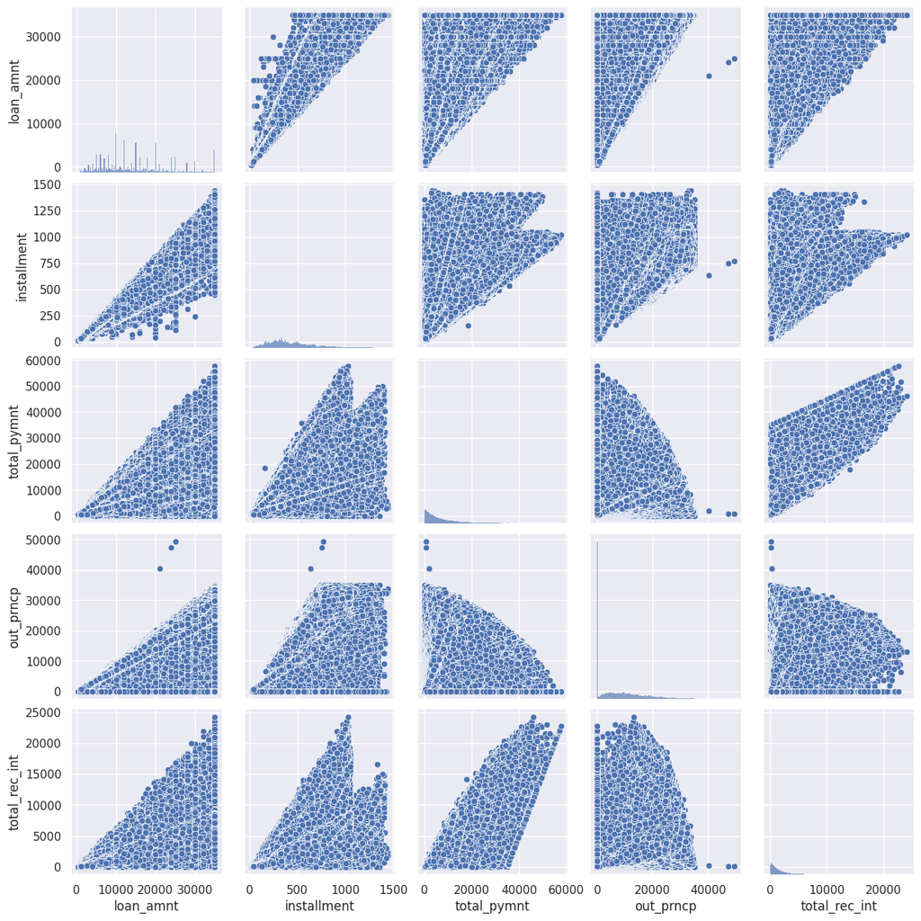

> Recomendaciones: usa funciones como `.info`, `.head` y `.duplicated`.

## Limpieza de datos

- Elimina los datos faltantes o duplicados con el método que sea más conveniente y justifica tu elección.
- Elimina las variables cuyo valor de completitud sea menor a 80; después, identifica y modifica aquellos valores atípicos (*outliers*).

### Imputación de datos

```
                        Nombre  Total  Completitud
0             total_rev_hi_lim  70276    92.080498
1                  tot_cur_bal  70276    92.080498
2                 tot_coll_amt  70276    92.080498
3                   revol_util    502    99.943429
4   collections_12_mths_ex_med    145    99.983660
5               inq_last_6mths     29    99.996732
6                    total_acc     29    99.996732
7                      pub_rec     29    99.996732
8                     open_acc     29    99.996732
9                  delinq_2yrs     29    99.996732
10              acc_now_delinq     29    99.996732
11                  annual_inc      4    99.999549
12             total_rec_prncp      0   100.000000
13             last_pymnt_amnt      0   100.000000
```

[output cut: 18 more lines]

```
['total_rev_hi_lim',
 'tot_cur_bal',
 'tot_coll_amt',
 'revol_util',
 'collections_12_mths_ex_med',
 'inq_last_6mths',
 'total_acc',
 'pub_rec',
 'open_acc',
 'delinq_2yrs',
 'acc_now_delinq',
 'annual_inc']
```

```
SimpleImputer()
```

### Revisión de *outliers*

|  | columna | outliers IQR | outliers Percentil | outliers cambio promedio | outliers IQR % | outliers Percentil % | outliers cambio promedio % | indices | outliers total | % outliers total |
| --- | --- | --- | --- | --- | --- | --- | --- | --- | --- | --- |
| 0 | c_loan_amnt | 0 | 86204 | 26 | 0.00 | 9.71 | 0.00 | [39442, 38932, 38936, 42136, 39331, 39466, 422... | 26 | 0.00 |
| 1 | c_funded_amnt | 0 | 86107 | 26 | 0.00 | 9.70 | 0.00 | [39442, 38932, 38936, 42136, 39331, 39466, 422... | 26 | 0.00 |
| 2 | c_funded_amnt_inv | 0 | 84100 | 478 | 0.00 | 9.48 | 0.05 | [41422, 41423, 41424, 41425, 41426, 41427, 414... | 478 | 0.05 |
| 3 | c_int_rate | 6308 | 83192 | 112 | 0.71 | 9.38 | 0.01 | [327680, 753667, 327684, 819204, 557063, 32769... | 6308 | 0.71 |
| 4 | c_installment | 23149 | 88608 | 80 | 2.61 | 9.99 | 0.01 | [524291, 393233, 655380, 131102, 655398, 52432... | 23227 | 2.62 |
| 5 | c_annual_inc | 39719 | 84768 | 1 | 4.48 | 9.55 | 0.00 | [524292, 655374, 524306, 655380, 262167, 39324... | 39719 | 4.48 |
| 6 | c_dti | 81 | 88687 | 2 | 0.01 | 9.99 | 0.00 | [524288, 542724, 541704, 519691, 555531, 48590... | 81 | 0.01 |
| 7 | c_delinq_2yrs | 170418 | 23614 | 1 | 19.20 | 2.66 | 0.00 | [131086, 655381, 27, 131100, 524318, 393249, 1... | 23614 | 2.66 |
| 8 | c_inq_last_6mths | 53834 | 16436 | 1 | 6.07 | 1.85 | 0.00 | [1, 65537, 393217, 688134, 294920, 753674, 425... | 16436 | 1.85 |
| 9 | c_open_acc | 27478 | 80113 | 8 | 3.10 | 9.03 | 0.00 | [524289, 655367, 524296, 524305, 524313, 65538... | 27485 | 3.10 |
| 10 | c_pub_rec | 135807 | 22512 | 1 | 15.30 | 2.54 | 0.00 | [262145, 262153, 524304, 524309, 655386, 65539... | 22512 | 2.54 |
| 11 | c_revol_bal | 48649 | 88734 | 1 | 5.48 | 10.00 | 0.00 | [524289, 524292, 786437, 393237, 262167, 65538... | 44367 | 5.00 |
| 12 | c_revol_util | 51 | 88222 | 1 | 0.01 | 9.94 | 0.00 | [811008, 487938, 404996, 808709, 283910, 49127... | 51 | 0.01 |
| 13 | c_total_acc | 18232 | 78744 | 84 | 2.05 | 8.87 | 0.01 | [622593, 131074, 622602, 589835, 884747, 98317... | 18315 | 2.06 |
| 14 | c_out_prncp | 3363 | 44354 | 1 | 0.38 | 5.00 | 0.00 | [499714, 466949, 540678, 483338, 507917, 46695... | 3363 | 0.38 |
| 15 | c_out_prncp_inv | 3311 | 44368 | 1 | 0.37 | 5.00 | 0.00 | [499714, 466949, 540678, 483338, 507917, 46695... | 3311 | 0.37 |
| 16 | c_total_pymnt | 46324 | 88737 | 1 | 5.22 | 10.00 | 0.00 | [786437, 131084, 393231, 20, 131093, 393241, 1... | 44368 | 5.00 |
| 17 | c_total_pymnt_inv | 46390 | 88738 | 1 | 5.23 | 10.00 | 0.00 | [786437, 131084, 393231, 20, 131093, 393241, 1... | 44369 | 5.00 |
| 18 | c_total_rec_prncp | 56944 | 85036 | 6234 | 6.42 | 9.58 | 0.70 | [786437, 655368, 131084, 393231, 20, 131093, 3... | 40667 | 4.58 |
| 19 | c_total_rec_int | 63836 | 88734 | 1 | 7.19 | 10.00 | 0.00 | [131075, 131078, 131079, 20, 131093, 393237, 1... | 44368 | 5.00 |
| 20 | c_total_rec_late_fee | 12517 | 12517 | 1 | 1.41 | 1.41 | 0.00 | [3, 196612, 229385, 229386, 524305, 18, 32796,... | 12517 | 1.41 |
| 21 | c_recoveries | 24677 | 24677 | 1 | 2.78 | 2.78 | 0.00 | [1, 262146, 8, 393224, 9, 12, 14, 24, 27, 1311... | 24677 | 2.78 |
| 22 | c_collection_recovery_fee | 23507 | 23507 | 2 | 2.65 | 2.65 | 0.00 | [1, 262146, 8, 393224, 9, 12, 14, 24, 27, 1311... | 23507 | 2.65 |
| 23 | c_last_pymnt_amnt | 156617 | 88738 | 11 | 17.65 | 10.00 | 0.00 | [786437, 131083, 393231, 262167, 393241, 31, 2... | 44369 | 5.00 |
| 24 | c_collections_12_mths_ex_med | 11826 | 11826 | 1 | 1.33 | 1.33 | 0.00 | [458754, 884742, 360456, 491528, 524298, 62260... | 11826 | 1.33 |
| 25 | c_policy_code | 0 | 0 | 0 | 0.00 | 0.00 | 0.00 | [] | 0 | 0.00 |
| 26 | c_acc_now_delinq | 4143 | 4143 | 1 | 0.47 | 0.47 | 0.00 | [475138, 450565, 737286, 679944, 548879, 62260... | 4143 | 0.47 |
| 27 | c_tot_coll_amt | 186433 | 44330 | 1 | 21.01 | 5.00 | 0.00 | [786432, 655362, 131075, 393219, 524295, 13108... | 44330 | 5.00 |
| 28 | c_tot_cur_bal | 35908 | 88735 | 1 | 4.05 | 10.00 | 0.00 | [655368, 524306, 131092, 655380, 655387, 39324... | 35908 | 4.05 |
| 29 | c_total_rev_hi_lim | 57237 | 88030 | 3 | 6.45 | 9.92 | 0.00 | [524289, 393221, 786437, 131087, 393233, 52430... | 44331 | 5.00 |

```
El número de valores atípicos es: 326449
La proporción de valores atípicos es: 36.79%
```

```
(560930, 32)
```

## Procesamiento de datos

Usa un transformador o los transformadores necesarios y justifica tu elección.

#### Transformación de variables categóricas

```
Para loan_status:
 Charged Off                                             42475
Current                                                308678
Default                                                   832
Does not meet the credit policy. Status:Charged Off       761
Does not meet the credit policy. Status:Fully Paid       1988
Fully Paid                                             185858
In Grace Period                                          3556
Issued                                                   8460
Late (16-30 days)                                        1323
Late (31-120 days)                                       6999
Name: loan_status, dtype: int64

Para term:
  36 months    402341
 60 months    158589
Name: term, dtype: int64

Para grade:
 A     91307
B    166047
C    152949
D     89573
E     42373
F     14986
G      3695
Name: grade, dtype: int64

Para purpose:
 car                     6220
credit_card           128068
debt_consolidation    327992
educational              422
home_improvement       32503
house                   2576
major_purchase         11710
medical                 5660
moving                  3532
other                  28695
renewable_energy         406
small_business          7831
vacation                2972
wedding                 2343
Name: purpose, dtype: int64
```

```
(560930, 36)
(560930, 32)
```

**Justificación**: Escogí realizar el codificado sobre esas cuatro variables categóricas porque son aquellas que considero más relevantes para cconstruir modelos de clasificación, por ejemplo, un modelo logit ordenado para saber las probabilidades de pago del préstamo de acuerdo al `grade` que pertenezcan o un modelo logit multinomial para clasificar la probabilidad de pago de acuerdo con el `loan_status` o `purpose` que se tenga.

### Escalamiento de datos

#### Método: Normalización

$$ X_{\text{norm}} = \frac{X - \mu}{\sigma} $$

```
array([[-1.43638174, -1.45925869, -1.09968655, ...,  2.10672176,
         0.34164191,  0.44945883],
       [-1.43639607, -1.45855403, -1.48172576, ...,  2.10672176,
         0.34164191,  0.44945883],
       [-1.43647598, -1.45862797, -1.39356287, ...,  2.10672176,
         0.34164191,  0.44945883],
       ...,
       [ 0.11876342,  0.11684834,  1.69213847, ..., -0.39180123,
         0.35008524, -0.99483601],
       [ 0.11129068,  0.10977248,  0.07581872, ..., -0.39180123,
        -0.73347141, -0.47969149],
       [ 0.11128756,  0.10976915,  1.10438583, ..., -0.39180123,
        -0.742366  ,  1.08555532]])
```

#### Método: Escala min-max

$$ X_{\text{norm}} = \frac{X - X_{min}}{X_{max} - X_{min}} $$

```
array([[0.01490285, 0.0166831 , 0.1202346 , ..., 0.40304038, 0.31615215,
        0.39936015],
       [0.0148981 , 0.01691345, 0.04398827, ..., 0.40304038, 0.31615215,
        0.39936015],
       [0.01487159, 0.01688928, 0.06158358, ..., 0.40304038, 0.31615215,
        0.39936015],
       ...,
       [0.53070044, 0.53191413, 0.67741935, ..., 0.        , 0.31802653,
        0.12702366],
       [0.52822194, 0.52960102, 0.35483871, ..., 0.        , 0.07748163,
        0.2241594 ],
       [0.52822091, 0.52959993, 0.5601173 , ..., 0.        , 0.07550707,
        0.51930262]])
```

### Comparación de métodos

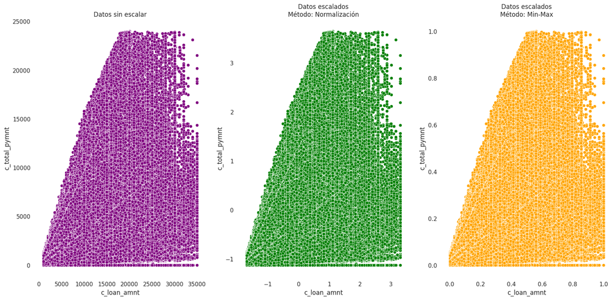

**Justificación**: Escogí comprobar ambos métodos de escalamiento, normalización y rango, para comprobar que la distribución de datos se mantiene para ambos métodos.

Personalmente prefiero trabajar con el método del rango porque la escala de la mayoría de los índices que utilizo es de 0 a 1.

## Reducción de dimensionalidades

Selecciona la mejor técnica para reducir las dimensiones y justifica por qué debe reducirse. Se recomienda indicar el número de dimensiones óptimo.

### Análisis de Componentes Principales (PCA)

#### Método para escoger el número de componentes óptimo

Basado en: https://medium.com/@nicolasarrioja/c%C3%B3mo-seleccionar-la-cantidad-de-componentes-en-pca-y-otros-usos-b455960964ce

Paso 1: Realizar el PCA con un número de componentes igual a las variables en el dataframe.

Paso 2: Calcular la varianza explicada acumulada.

Paso 3: Decidir el porcentaje deseado: 90%

Paso 4: Dos formas:

- Graficar la varianza acumulada y el número de componentes.
- Identificar el índice (componente) asociado con el porcentaje deseado.

Paso 5: Realizar un nuevo PCA con el número de componentes óptimo.

##### Paso 1

```
El número de variables en el dataframe estandarizado es: 32
```

##### Paso 2

```
array([0.25485814, 0.46843878, 0.55400579, 0.62012284, 0.67402918,
       0.71981705, 0.76219063, 0.80088986, 0.83606762, 0.86927791,
       0.89705775, 0.92059658, 0.94292144, 0.95846143, 0.97175464,
       0.98326802, 0.99080742, 0.99477919, 0.99778282, 0.99972335,
       0.99994402, 0.99997656, 0.9999957 , 0.99999988, 1.        ,
       1.        , 1.        , 1.        , 1.        , 1.        ,
       1.        , 1.        ])
```

##### Paso 3

##### Paso 4

###### Forma escrita

```
El Número de componentes para el 90.00% de varianza acumulada es: 12
```

###### Forma gráfica

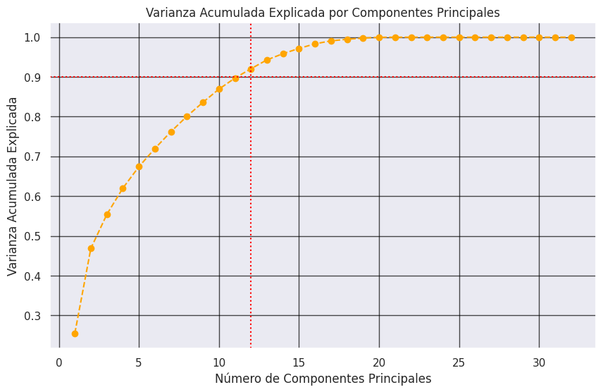

##### Paso 5

```
array([0.25485814, 0.46843878, 0.55400579, 0.62012284, 0.67402918,
       0.71981705, 0.76219063, 0.80088986, 0.83606762, 0.86927791,
       0.89705775, 0.92059658])
```

#### Comparar PCA

```
La matriz de covarianza para el modelo con 12 componentes es:
```

|  | Componente_1 | Componente_2 | Componente_3 | Componente_4 | Componente_5 | Componente_6 | Componente_7 | Componente_8 | Componente_9 | Componente_10 | Componente_11 | Componente_12 |
| --- | --- | --- | --- | --- | --- | --- | --- | --- | --- | --- | --- | --- |
| Componente_1 | 1.000000 | 0.000000 | -0.000000 | 0.000000 | -0.000000 | 0.000000 | -0.000000 | 0.000000 | -0.000000 | -0.000000 | 0.000000 | -0.000000 |
| Componente_2 | 0.000000 | 1.000000 | -0.000000 | -0.000000 | 0.000000 | -0.000000 | 0.000000 | -0.000000 | 0.000000 | 0.000000 | -0.000000 | 0.000000 |
| Componente_3 | -0.000000 | -0.000000 | 1.000000 | 0.000000 | -0.000000 | -0.000000 | -0.000000 | 0.000000 | 0.000000 | 0.000000 | 0.000000 | -0.000000 |
| Componente_4 | 0.000000 | -0.000000 | 0.000000 | 1.000000 | 0.000000 | 0.000000 | 0.000000 | -0.000000 | 0.000000 | -0.000000 | 0.000000 | -0.000000 |
| Componente_5 | -0.000000 | 0.000000 | -0.000000 | 0.000000 | 1.000000 | -0.000000 | 0.000000 | -0.000000 | -0.000000 | -0.000000 | 0.000000 | 0.000000 |
| Componente_6 | 0.000000 | -0.000000 | -0.000000 | 0.000000 | -0.000000 | 1.000000 | 0.000000 | 0.000000 | 0.000000 | 0.000000 | -0.000000 | -0.000000 |
| Componente_7 | -0.000000 | 0.000000 | -0.000000 | 0.000000 | 0.000000 | 0.000000 | 1.000000 | -0.000000 | -0.000000 | 0.000000 | 0.000000 | 0.000000 |
| Componente_8 | 0.000000 | -0.000000 | 0.000000 | -0.000000 | -0.000000 | 0.000000 | -0.000000 | 1.000000 | 0.000000 | 0.000000 | -0.000000 | 0.000000 |
| Componente_9 | -0.000000 | 0.000000 | 0.000000 | 0.000000 | -0.000000 | 0.000000 | -0.000000 | 0.000000 | 1.000000 | -0.000000 | 0.000000 | -0.000000 |
| Componente_10 | -0.000000 | 0.000000 | 0.000000 | -0.000000 | -0.000000 | 0.000000 | 0.000000 | 0.000000 | -0.000000 | 1.000000 | -0.000000 | 0.000000 |
| Componente_11 | 0.000000 | -0.000000 | 0.000000 | 0.000000 | 0.000000 | -0.000000 | 0.000000 | -0.000000 | 0.000000 | -0.000000 | 1.000000 | -0.000000 |
| Componente_12 | -0.000000 | 0.000000 | -0.000000 | -0.000000 | 0.000000 | -0.000000 | 0.000000 | 0.000000 | -0.000000 | 0.000000 | -0.000000 | 1.000000 |

> Recuerda incluir en tu análisis los gráficos adecuados para comunicar lo que deseas expresar. Para favorecer tu entendimiento del programa, se sugiere el uso de comentarios (#) en cada bloque de código.

[output not shown]